# Milestone 1: NY State Report Card

The New York State School Report Card, 2024-25 release, tracks spending, test scores, attendance, and teacher staffing for every district and school in the state. Read together, those tables speak to three questions:

1. How does money affect pupil performance at these schools?
2. How have test scores trended over the last few years, and what does the increase/dropoff look like for affluent schools versus poorer schools? And how does it compare in math versus reading?
3. In what ways are disadvantaged schools disadvantaged versus their peers?

A longer run of data would open a fourth question: how AI and social media track with changes in student performance over time.

## Data loading

The database has around 30 tables. The ones that look useful for the questions are the math and ELA exam tables, the expenditures table, the chronic absenteeism table, and the two teacher tables (inexperienced teachers and out-of-certification teachers).

The exam tables are pretty big (around 650k rows each) because every row is a school × assessment × subgroup combination. The expenditure and teacher tables are at the district level, which is one row per district per year, so they’re much smaller.

The dataset covers only 2024 and 2025, so any trend here rests on just two data points. Earlier SRC releases would extend that window for the final.

The exam tables already break each result down into a long list of subgroups (Economically Disadvantaged, English Language Learner, race/ethnicity, gender, homeless, foster care, etc.). That’s helpful, because it already provides a definition of disadvantaged.

MATH3_8 is a roll-up summary, but its MEAN_SCORE column is empty. The grade-level rows (MATH3 through MATH8) carry the actual scale scores, so those are the rows behind every comparable number below.

The ENTITY_CD column is a 12-digit code identifying both districts and schools. District codes end in 0000; school codes do not. The expenditures table mixes both, so the joins below keep only district rows, since the aggregate is what matters.

Around 700 districts and 4500 schools.

## Goal 1: Does money buy performance?

The intuitive expectation is simple: districts that spend more per pupil should score higher. Plotting per-pupil spending against average math scores tests it directly.

### The puzzle: spending and scores move in the wrong direction

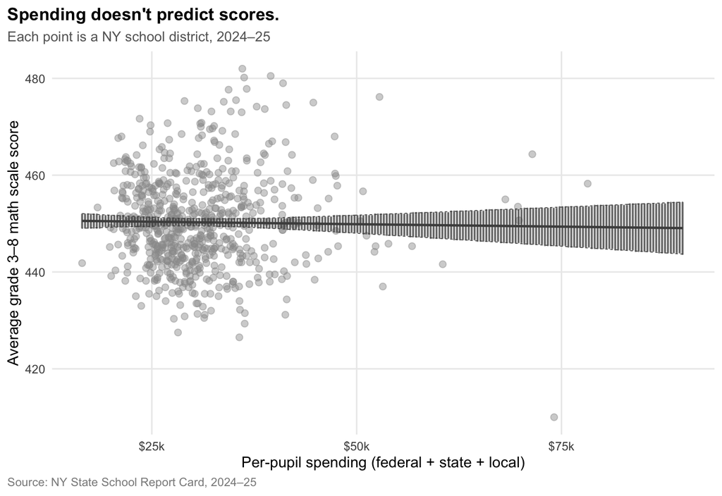

There’s no upward pattern. If anything, higher spending is weakly associated with *lower* scores, the reverse of that expectation. So what explains it?

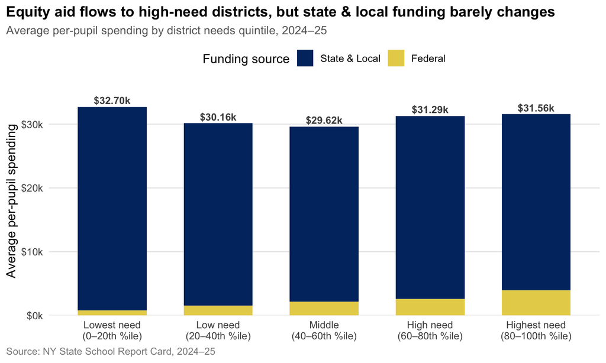

### The real driver: poverty, not spending

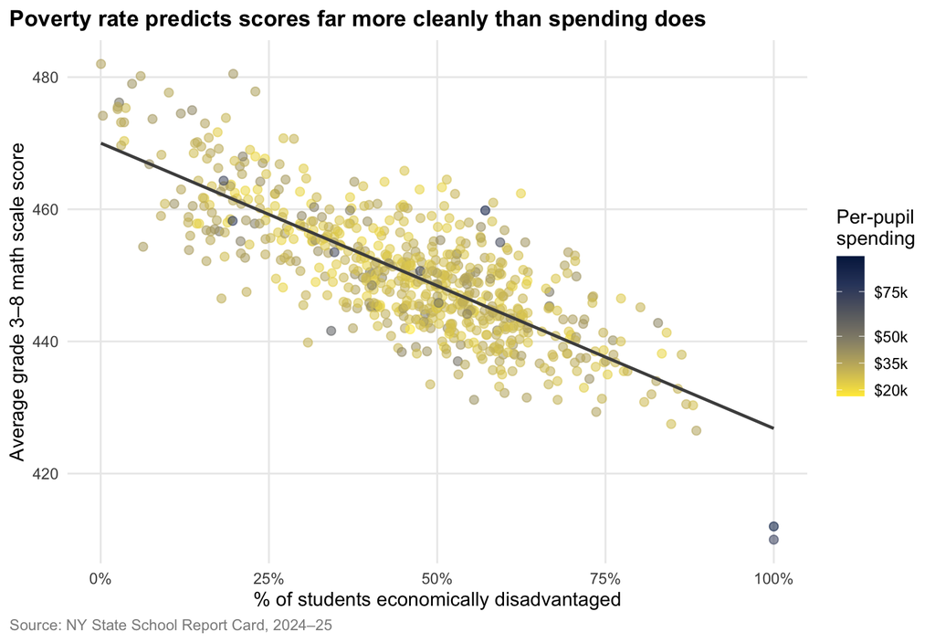

Poverty rate is a strong predictor of scores (r = -0.79), far more so than spending (r = -0.02). That raises the next question: how wide is this gap, and is it closing?

## Goal 2: Affluent vs poorer schools in math and reading

If poverty predicts scores more cleanly than spending, the next question is how wide that gap actually is, and whether it’s moving. Across grades 3 to 8, economically disadvantaged students sit roughly 13 to 14 scale-score points behind their peers in both math and ELA, and that gap barely moves between 2024 and 2025. Math runs a hair wider than ELA, but the two subjects don’t share a scale, so that’s a soft observation. Two years is a short window, though, and the longer view is more revealing.

### The longer view: COVID broke the trend

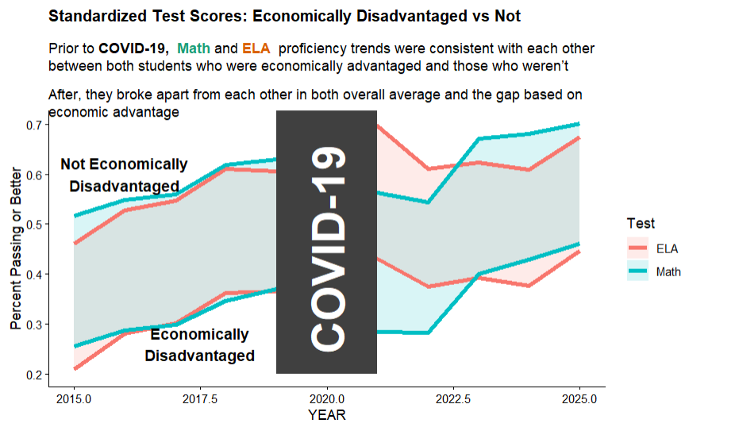

Standardized test scores: economically disadvantaged vs not, ELA and Math, 2015–2025

Before the pandemic, both groups climbed together. After, math fell harder than ELA for economically disadvantaged students, and they haven’t recovered to their pre-pandemic trajectory the way their peers have. The flat 2024–2025 gap isn’t steady state. It’s the tail end of a bigger setback.

## Goal 3: How are disadvantaged schools disadvantaged?

A gap this wide and this stuck rarely runs on student effort alone. Two structural mechanisms are measurable in this dataset: how often students show up, and who’s teaching them. Attendance comes first, and it is far from equal across subgroups.

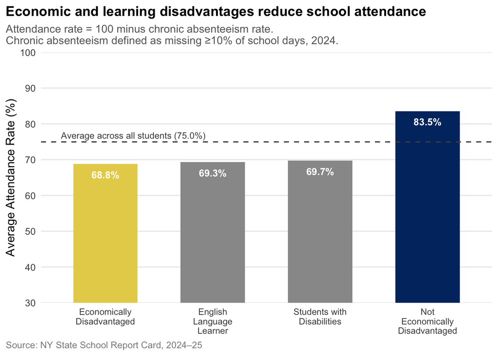

Economically disadvantaged students miss roughly twice as much school as their peers. An academic gap can’t close from outside the building, which makes absenteeism a plausible cause and not just a symptom.

### High-need districts shoulder rougher staffing too

Teacher data isn’t broken out by student subgroup, so the lens shifts to the district level: do high-need districts get a worse staffing deal?

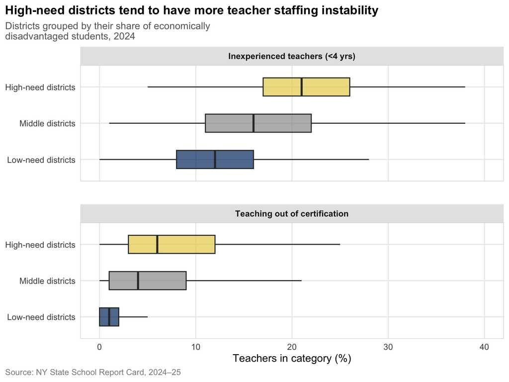

High-need districts carry higher shares of inexperienced teachers and teachers working out of certification. Within each need group the pattern isn’t identical district to district, but the spread shifts upward as need rises, with a heavier tail where teacher instability runs unusually high. The disadvantage extends beyond student test scores into less stable teacher staffing, part of what high-need districts are up against.